# Modelos de Regresion Lineal — CMI (Cummins Inc.)

**Alumna:** Mariann Antonelli Morales Tobias | **Matricula:** A01452078

**Curso:** Econometria Financiera | **Proyecto Final**

**Variable dependiente:** CMI (Cummins Inc.) | **Periodo:** 2024-03-14 a 2026-03-14 | **Fuente:** Yahoo Finance — rendimientos logaritmicos diarios (%)

## 1. Portafolio de Acciones

| Ticker | Empresa | Sector |
| --- | --- | --- |
| **CAT** | Caterpillar Inc. | OEM Maquinaria Pesada |
| **DE** | Deere & Company | OEM Maquinaria Agrícola |
| **PCAR** | PACCAR Inc. | OEM Camiones Pesados |
| **NUE** | Nucor Corporation | Producción de Acero (Materia Prima) |
| **PH** | Parker-Hannifin Corporation | Componentes Industriales (Proveedor OEM) |
| **ETN** | Eaton Corporation | Equipos Eléctricos (Proveedor OEM) |
| **HON** | Honeywell International Inc. | Tecnología Industrial (Proveedor OEM) |
| **OSK** | Oshkosh Corporation | OEM Vehículos Especializados |
| **XOM** | Exxon Mobil Corporation | Energía (Petróleo y Gas) |

## 2. Matriz de Correlacion

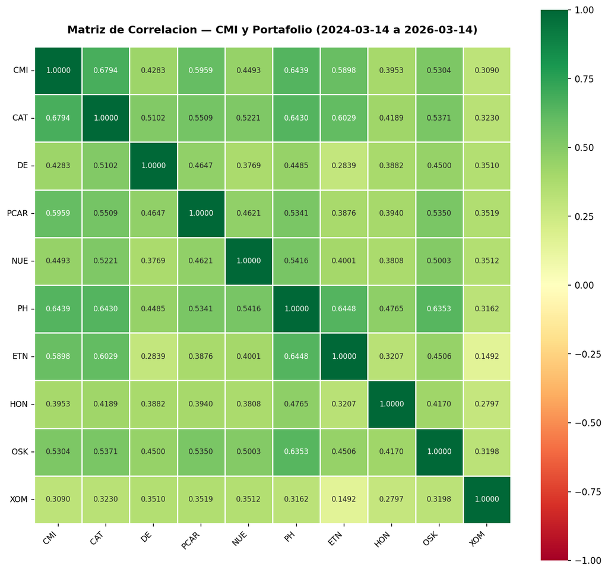

### Correlaciones con CMI (mayor a menor)

| Ticker | Empresa | Sector | Correlacion | Nivel |
| --- | --- | --- | --- | --- |
| **CAT** | Caterpillar Inc. | OEM Maquinaria Pesada | 0.6794 | Alta |
| **PH** | Parker-Hannifin Corporation | Componentes Industriales (Proveedor OEM) | 0.6439 | Alta |
| **PCAR** | PACCAR Inc. | OEM Camiones Pesados | 0.5959 | Alta |
| **ETN** | Eaton Corporation | Equipos Eléctricos (Proveedor OEM) | 0.5898 | Alta |
| **OSK** | Oshkosh Corporation | OEM Vehículos Especializados | 0.5304 | Alta |
| **NUE** | Nucor Corporation | Producción de Acero (Materia Prima) | 0.4493 | Moderada |
| **DE** | Deere & Company | OEM Maquinaria Agrícola | 0.4283 | Moderada |
| **HON** | Honeywell International Inc. | Tecnología Industrial (Proveedor OEM) | 0.3953 | Moderada |
| **XOM** | Exxon Mobil Corporation | Energía (Petróleo y Gas) | 0.3090 | Moderada |

## 3. Regresiones Lineales Simples

Modelo: **CMI_ret = b0 + b1 * X_ret + e**

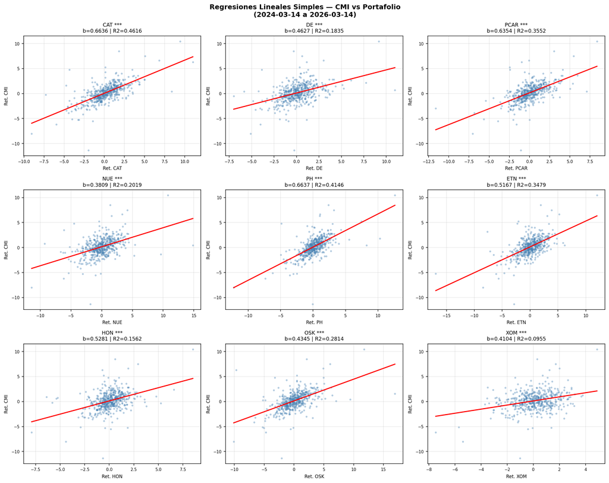

### Tabla Resumen

| Ticker | Empresa | Sector | b1 | P-value | R2 | R2 Aj. | F-stat | Significancia |
| --- | --- | --- | --- | --- | --- | --- | --- | --- |
| **CAT** | Caterpillar Inc. | OEM Maquinaria Pesada | 0.6636 | 0.0000 | 0.4616 | 0.4605 | 426.9641 | *** |
| **DE** | Deere & Company | OEM Maquinaria Agrícola | 0.4627 | 0.0000 | 0.1835 | 0.1818 | 111.8882 | *** |
| **PCAR** | PACCAR Inc. | OEM Camiones Pesados | 0.6354 | 0.0000 | 0.3552 | 0.3539 | 274.2758 | *** |
| **NUE** | Nucor Corporation | Producción de Acero (Materia Prima) | 0.3809 | 0.0000 | 0.2019 | 0.2003 | 125.9592 | *** |
| **PH** | Parker-Hannifin Corporation | Componentes Industriales (Proveedor OEM) | 0.6637 | 0.0000 | 0.4146 | 0.4135 | 352.7662 | *** |
| **ETN** | Eaton Corporation | Equipos Eléctricos (Proveedor OEM) | 0.5167 | 0.0000 | 0.3479 | 0.3466 | 265.6398 | *** |
| **HON** | Honeywell International Inc. | Tecnología Industrial (Proveedor OEM) | 0.5281 | 0.0000 | 0.1562 | 0.1546 | 92.2186 | *** |
| **OSK** | Oshkosh Corporation | OEM Vehículos Especializados | 0.4345 | 0.0000 | 0.2814 | 0.2799 | 194.9694 | *** |
| **XOM** | Exxon Mobil Corporation | Energía (Petróleo y Gas) | 0.4104 | 0.0000 | 0.0955 | 0.0937 | 52.5749 | *** |

Significancia: *** p<0.001 | ** p<0.01 | * p<0.05 | ns no significativo

**Mejor predictor individual:** CAT (Caterpillar Inc.) — R2 = 0.4616

## 4. Regresion Lineal Multiple

0.5939

R2

0.5864

R2 Ajustado

79.6086

F-statistic

0.0000

P-value F

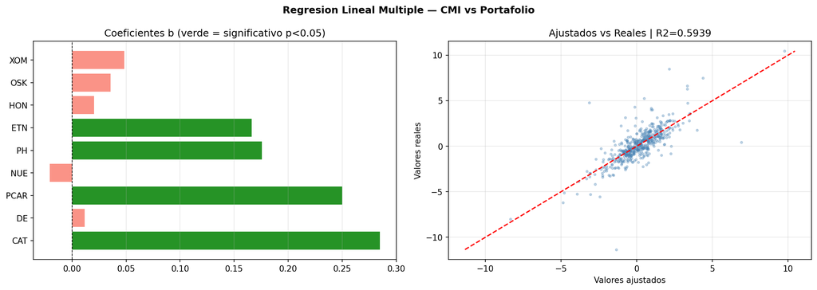

### Coeficientes OLS

| Ticker | Empresa | Sector | Coeficiente b | P-value | Significancia |
| --- | --- | --- | --- | --- | --- |
| **CAT** | Caterpillar Inc. | OEM Maquinaria Pesada | 0.284834 | 0.0000 | *** |
| **DE** | Deere & Company | OEM Maquinaria Agrícola | 0.011863 | 0.7615 | ns |
| **PCAR** | PACCAR Inc. | OEM Camiones Pesados | 0.250169 | 0.0000 | *** |
| **NUE** | Nucor Corporation | Producción de Acero (Materia Prima) | -0.020484 | 0.5153 | ns |
| **PH** | Parker-Hannifin Corporation | Componentes Industriales (Proveedor OEM) | 0.175680 | 0.0004 | *** |
| **ETN** | Eaton Corporation | Equipos Eléctricos (Proveedor OEM) | 0.166191 | 0.0000 | *** |
| **HON** | Honeywell International Inc. | Tecnología Industrial (Proveedor OEM) | 0.020245 | 0.6588 | ns |
| **OSK** | Oshkosh Corporation | OEM Vehículos Especializados | 0.035790 | 0.2803 | ns |
| **XOM** | Exxon Mobil Corporation | Energía (Petróleo y Gas) | 0.048445 | 0.2625 | ns |

Significancia: *** p<0.001 | ** p<0.01 | * p<0.05 | ns no significativo

### Tabla Comparativa OLS vs GLS

| Ticker | Empresa | OLS coef / p-value (sig) | GLS coef / p-value (sig) | Cambio |
| --- | --- | --- | --- | --- |
| **CAT** | Caterpillar Inc. | 0.284834 p=0.0000 *** | 0.284834 p=0.0000 *** | Sin cambio |
| **DE** | Deere & Company | 0.011863 p=0.7615 **ns** | 0.011863 p=0.7615 **ns** | Sin cambio |
| **PCAR** | PACCAR Inc. | 0.250169 p=0.0000 *** | 0.250169 p=0.0000 *** | Sin cambio |
| **NUE** | Nucor Corporation | -0.020484 p=0.5153 **ns** | -0.020484 p=0.5153 **ns** | Sin cambio |
| **PH** | Parker-Hannifin Corporation | 0.175680 p=0.0004 *** | 0.175680 p=0.0004 *** | Sin cambio |
| **ETN** | Eaton Corporation | 0.166191 p=0.0000 *** | 0.166191 p=0.0000 *** | Sin cambio |
| **HON** | Honeywell International Inc. | 0.020245 p=0.6588 **ns** | 0.020245 p=0.6588 **ns** | Sin cambio |
| **OSK** | Oshkosh Corporation | 0.035790 p=0.2803 **ns** | 0.035790 p=0.2803 **ns** | Sin cambio |
| **XOM** | Exxon Mobil Corporation | 0.048445 p=0.2625 **ns** | 0.048445 p=0.2625 **ns** | Sin cambio |
| R2 / R2 ajustado |  | 0.5939 / 0.5864 | 0.8263 / 0.8231 |  |

ADVERTENCIA: Heterocedasticidad detectada. Se aplico correccion GLS. Las filas en amarillo indican cambio en la significancia estadistica.

### Tabla Comparativa OLS vs Newey-West (HAC)

Newey-West **no cambia los coeficientes** — solo corrige los errores estandar (SE) por la presencia de autocorrelacion, lo que puede cambiar los p-values y la significancia. Las filas en amarillo indican un cambio en la significancia estadistica.

| Ticker | Empresa | OLS coef \| SE \| p-value (sig) | Newey-West (HAC) coef \| SE \| p-value (sig) | Cambio |
| --- | --- | --- | --- | --- |
| **CAT** | Caterpillar Inc. | 0.284834 SE=0.043398 \| p=0.0000 *** | 0.284834 SE=0.065826 \| p=0.0000 *** | Sin cambio |
| **DE** | Deere & Company | 0.011863 SE=0.039070 \| p=0.7615 **ns** | 0.011863 SE=0.035378 \| p=0.7375 **ns** | Sin cambio |
| **PCAR** | PACCAR Inc. | 0.250169 SE=0.040898 \| p=0.0000 *** | 0.250169 SE=0.041394 \| p=0.0000 *** | Sin cambio |
| **NUE** | Nucor Corporation | -0.020484 SE=0.031463 \| p=0.5153 **ns** | -0.020484 SE=0.046187 \| p=0.6576 **ns** | Sin cambio |
| **PH** | Parker-Hannifin Corporation | 0.175680 SE=0.049233 \| p=0.0004 *** | 0.175680 SE=0.104482 \| p=0.0933 **ns** | CAMBIO en sig. |
| **ETN** | Eaton Corporation | 0.166191 SE=0.035391 \| p=0.0000 *** | 0.166191 SE=0.049876 \| p=0.0009 *** | Sin cambio |
| **HON** | Honeywell International Inc. | 0.020245 SE=0.045818 \| p=0.6588 **ns** | 0.020245 SE=0.040085 \| p=0.6137 **ns** | Sin cambio |
| **OSK** | Oshkosh Corporation | 0.035790 SE=0.033115 \| p=0.2803 **ns** | 0.035790 SE=0.042576 \| p=0.4010 **ns** | Sin cambio |
| **XOM** | Exxon Mobil Corporation | 0.048445 SE=0.043189 \| p=0.2625 **ns** | 0.048445 SE=0.044442 \| p=0.2762 **ns** | Sin cambio |

ADVERTENCIA: Autocorrelacion detectada. Se corrigieron los errores estandar con Newey-West (HAC, lag=10). Las filas en amarillo indican cambio en la significancia estadistica tras la correccion.

## 5. Diagnosticos del Modelo

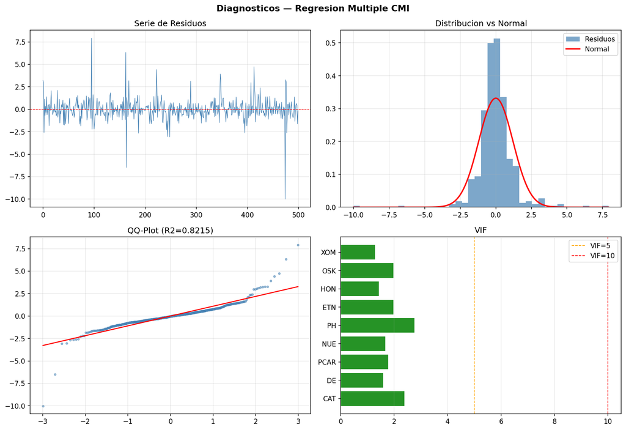

### 5.1 Multicolinealidad — VIF

| Ticker | Empresa | VIF | Diagnostico |
| --- | --- | --- | --- |
| **CAT** | Caterpillar Inc. | 2.3816 | Sin problema |
| **DE** | Deere & Company | 1.5783 | Sin problema |
| **PCAR** | PACCAR Inc. | 1.7750 | Sin problema |
| **NUE** | Nucor Corporation | 1.6620 | Sin problema |
| **PH** | Parker-Hannifin Corporation | 2.7524 | Sin problema |
| **ETN** | Eaton Corporation | 1.9689 | Sin problema |
| **HON** | Honeywell International Inc. | 1.4189 | Sin problema |
| **OSK** | Oshkosh Corporation | 1.9717 | Sin problema |
| **XOM** | Exxon Mobil Corporation | 1.2761 | Sin problema |
| Resumen |  | Max: 2.7524 \| Prom: 1.865 | VIF < 5 sin problema \| 5-10 moderada \| >10 severa |

### 5.2 Heterocedasticidad

| Prueba | P-value | Conclusion |
| --- | --- | --- |
| Breusch-Pagan | 0.5505 | OK — Homocedasticidad |
| Goldfeld-Quandt | 0.8695 | OK — Homocedasticidad |
| White Test | 0.0055 | Heterocedasticidad detectada |

ADVERTENCIA: Heterocedasticidad detectada. Se aplico correccion GLS. Ver tabla comparativa en Seccion 4.

### 5.3 Autocorrelacion

| Prueba | P-value | Conclusion |
| --- | --- | --- |
| Ljung-Box (lag=10) | 0.0069 | Autocorrelacion detectada |

ADVERTENCIA: Autocorrelacion detectada. Se corrigieron errores estandar con Newey-West (HAC). Ver tabla comparativa en Seccion 4.

Documento generado automaticamente en Google Colab

Mariann Antonelli Morales Tobias | A01452078 | Econometria Financiera 2026